# Essential Statistical Data Analysis

Class 2 Lab — Classification: from probabilities to decisions

Author

Published

May 18, 2026

# Lab overview

In this lab, we practise the main steps of a classification analysis:

- identifying a categorical response variable;
- splitting data into training and test sets;
- fitting a classification model;
- obtaining predicted probabilities;
- converting probabilities into predicted classes;
- evaluating predictions with confusion matrices;
- changing the classification threshold;
- drawing ROC curves and computing AUC;
- comparing different classifiers.

You can edit the code chunks directly and re-run them.

# Part 1 — The classification problem

We use the `penguins` dataset from the `palmerpenguins` package.

Each row describes one penguin. The variables include species, island, bill measurements, flipper length, body mass, sex, and year.

To focus on binary classification, we create a new response variable:

$$\texttt{adelie} =
\begin{cases}
\text{Yes}, & \text{if the penguin is Adelie} \\
\text{No}, & \text{otherwise}
\end{cases}$$

The goal is to predict whether a penguin is an Adelie penguin from its measurements.

## Lab 1 — Load and prepare the data

```r
penguins_binary <- palmerpenguins::penguins |>
  drop_na(
    species,
    bill_length_mm,
    bill_depth_mm,
    flipper_length_mm,
    body_mass_g,
    island,
    sex
  ) |>
  mutate(
    adelie = factor(
      if_else(species == "Adelie", "Yes", "No"),
      levels = c("No", "Yes")
    ),
    species = as.factor(species),
    island = as.factor(island),
    sex = as.factor(sex)
  )

glimpse(penguins_binary)
```

```
Rows: 333
Columns: 9
$ species           <fct> Adelie, Adelie, Adelie, Adelie, Adelie, Adelie, Adel…
$ island            <fct> Torgersen, Torgersen, Torgersen, Torgersen, Torgerse…
$ bill_length_mm    <dbl> 39.1, 39.5, 40.3, 36.7, 39.3, 38.9, 39.2, 41.1, 38.6…
$ bill_depth_mm     <dbl> 18.7, 17.4, 18.0, 19.3, 20.6, 17.8, 19.6, 17.6, 21.2…
$ flipper_length_mm <int> 181, 186, 195, 193, 190, 181, 195, 182, 191, 198, 18…
$ body_mass_g       <int> 3750, 3800, 3250, 3450, 3650, 3625, 4675, 3200, 3800…
$ sex               <fct> male, female, female, female, male, female, male, fe…
$ year              <int> 2007, 2007, 2007, 2007, 2007, 2007, 2007, 2007, 2007…
$ adelie            <fct> Yes, Yes, Yes, Yes, Yes, Yes, Yes, Yes, Yes, Yes, Ye…
```

**TipYour turn**

Identify:

1. the observational unit;
2. the response variable;
3. the predictor variables we could use.

Write your answer here:

```markdown
Observational unit:

Response variable:

Possible predictor variables:
```

## Lab 2 — Class frequencies

Before fitting a classifier, we should inspect the distribution of the response variable.

```r
penguins_binary |>
  count(adelie)
```

```
# A tibble: 2 × 2
  adelie     n
  <fct>  <int>
1 No       187
2 Yes      146
```

```r
penguins_binary |>
  count(adelie) |>
  mutate(proportion = n / sum(n))
```

```
# A tibble: 2 × 3
  adelie     n proportion
  <fct>  <int>      <dbl>
1 No       187      0.562
2 Yes      146      0.438
```

**TipYour turn**

Is this a balanced or imbalanced classification problem?  
Which class is more frequent?

Write your answer here:

```markdown
Answer:
```

# Part 2 — Exploring predictors and classes

## Lab 3 — Bill length and Adelie status

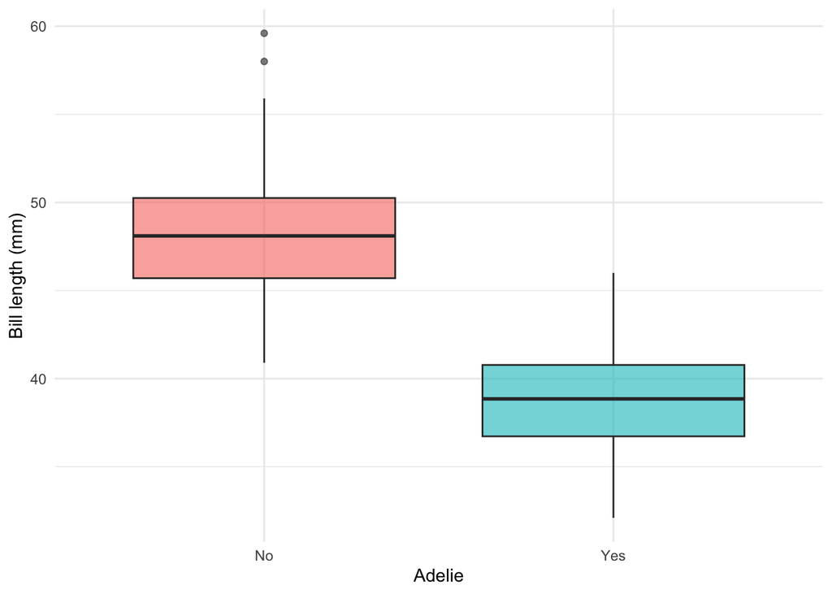

```r
penguins_binary |>
  ggplot(aes(x = adelie, y = bill_length_mm, fill = adelie)) +
  geom_boxplot(alpha = 0.6, show.legend = FALSE) +
  labs(
    x = "Adelie",
    y = "Bill length (mm)"
  )
```

**TipYour turn**

Does `bill_length_mm` look useful for predicting whether a penguin is Adelie?  
Why?

Write your interpretation here:

```markdown
Interpretation:
```

## Lab 4 — Bill depth and Adelie status

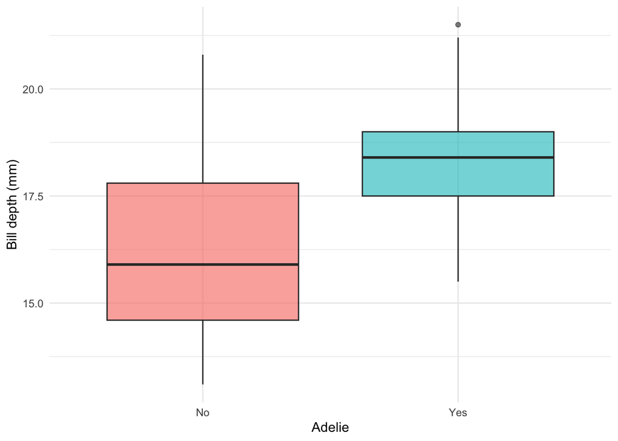

```r
penguins_binary |>
  ggplot(aes(x = adelie, y = bill_depth_mm, fill = adelie)) +
  geom_boxplot(alpha = 0.6, show.legend = FALSE) +
  labs(
    x = "Adelie",
    y = "Bill depth (mm)"
  )
```

**TipYour turn**

Does `bill_depth_mm` look useful for distinguishing Adelie penguins from other penguins?

Write your interpretation here:

```markdown
Interpretation:
```

## Lab 5 — Two predictors at once

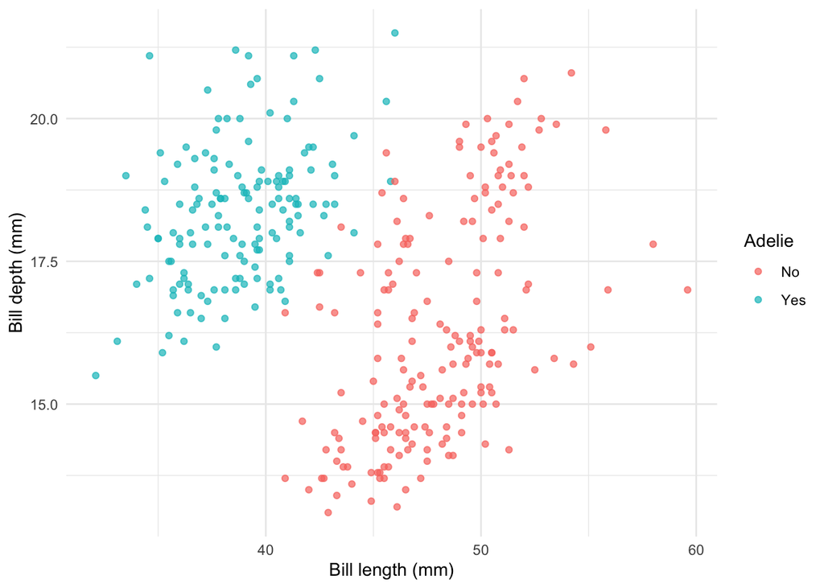

```r
penguins_binary |>
  ggplot(aes(x = bill_length_mm, y = bill_depth_mm, colour = adelie)) +
  geom_point(alpha = 0.7) +
  labs(
    x = "Bill length (mm)",
    y = "Bill depth (mm)",
    colour = "Adelie"
  )
```

**TipYour turn**

What do you notice about the position of Adelie penguins in the plot?

Write your interpretation here:

```markdown
Interpretation:
```

# Part 3 — Training and test data

## Lab 6 — Split the data

We split the data into:

- a training set, used to fit the model;
- a test set, used to evaluate predictions on new observations.

```r
set.seed(1234)

peng_split <- initial_split(
  penguins_binary,
  prop = 3/4,
  strata = adelie
)

peng_train <- training(peng_split)
peng_test <- testing(peng_split)
```

```r
peng_train |>
  count(adelie) |>
  mutate(proportion = n / sum(n))
```

```
# A tibble: 2 × 3
  adelie     n proportion
  <fct>  <int>      <dbl>
1 No       140      0.562
2 Yes      109      0.438
```

```r
peng_test |>
  count(adelie) |>
  mutate(proportion = n / sum(n))
```

```
# A tibble: 2 × 3
  adelie     n proportion
  <fct>  <int>      <dbl>
1 No        47      0.560
2 Yes       37      0.440
```

**TipYour turn**

Why did we use `strata = adelie` when splitting the data?

Write your answer here:

```markdown
Answer:
```

# Part 4 — Logistic regression

## Lab 7 — Recipe, model, workflow

We first fit a logistic regression with one predictor: `bill_length_mm`.

```r
peng_rec <- recipe(adelie ~ bill_length_mm, data = peng_train)

peng_log_spec <- logistic_reg(
  mode = "classification",
  engine = "glm"
)

peng_log_wflow <- workflow() |>
  add_recipe(peng_rec) |>
  add_model(peng_log_spec)

peng_log_fit <- peng_log_wflow |>
  fit(data = peng_train)
```

**Note**

## Lab 8 — Look at the fitted model

```r
peng_log_fit |>
  tidy()
```

```
# A tibble: 2 × 5
  term           estimate std.error statistic  p.value
  <chr>             <dbl>     <dbl>     <dbl>    <dbl>
1 (Intercept)       50.4      8.21       6.14 8.46e-10
2 bill_length_mm    -1.18     0.192     -6.12 9.30e-10
```

**TipYour turn**

Look at the sign of the coefficient for `bill_length_mm`.  
Does the probability of being Adelie increase or decrease when bill length increases?

Write your answer here:

```markdown
Answer:
```

## Lab 9 — Predicted classes and probabilities

A classifier can return:

- a predicted class;
- predicted probabilities for each class.

```r
log_pred <- peng_log_fit |>
  augment(new_data = peng_test)

log_pred |>
  select(adelie, bill_length_mm, .pred_class, .pred_No, .pred_Yes) |>
  slice_head(n = 10) |>
  kbl() |>
  kable_styling(full_width = FALSE)
```

| adelie | bill_length_mm | .pred_class | .pred_No | .pred_Yes |
| --- | --- | --- | --- | --- |
| Yes | 39.1 | Yes | 0.0124725 | 0.9875275 |
| Yes | 39.3 | Yes | 0.0157299 | 0.9842701 |
| Yes | 38.6 | Yes | 0.0069639 | 0.9930361 |
| Yes | 37.8 | Yes | 0.0027282 | 0.9972718 |
| Yes | 37.6 | Yes | 0.0021574 | 0.9978426 |
| Yes | 39.6 | Yes | 0.0222409 | 0.9777591 |
| Yes | 42.0 | Yes | 0.2770247 | 0.7229753 |
| Yes | 41.4 | Yes | 0.1590540 | 0.8409460 |
| Yes | 39.0 | Yes | 0.0111033 | 0.9888967 |
| Yes | 40.6 | Yes | 0.0687125 | 0.9312875 |

**TipYour turn**

For the first 10 observations, find one observation with relatively high predicted probability of being Adelie.

Write your answer here:

```markdown
Answer:
```

# Part 5 — From probabilities to decisions

## Lab 10 — Default threshold

By default, predicted probabilities are usually converted into classes using threshold 0.5:

$$\widehat{P}(\text{Adelie} = \text{Yes} \mid X) > 0.5$$

```r
log_pred <- log_pred |>
  mutate(
    pred_0_5 = factor(
      if_else(.pred_Yes > 0.5, "Yes", "No"),
      levels = levels(peng_test$adelie)
    )
  )

log_pred |>
  select(adelie, .pred_Yes, .pred_class, pred_0_5) |>
  slice_head(n = 10)
```

```
# A tibble: 10 × 4
   adelie .pred_Yes .pred_class pred_0_5
   <fct>      <dbl> <fct>       <fct>
 1 Yes        0.988 Yes         Yes
 2 Yes        0.984 Yes         Yes
 3 Yes        0.993 Yes         Yes
 4 Yes        0.997 Yes         Yes
 5 Yes        0.998 Yes         Yes
 6 Yes        0.978 Yes         Yes
 7 Yes        0.723 Yes         Yes
 8 Yes        0.841 Yes         Yes
 9 Yes        0.989 Yes         Yes
10 Yes        0.931 Yes         Yes
```

**TipYour turn**

Are `.pred_class` and `pred_0_5` the same for the first 10 observations?

Write your answer here:

```markdown
Answer:
```

## Lab 11 — Confusion matrix

```r
log_pred |>
  conf_mat(truth = adelie, estimate = .pred_class)
```

```
          Truth
Prediction No Yes
       No  46   2
       Yes  1  35
```

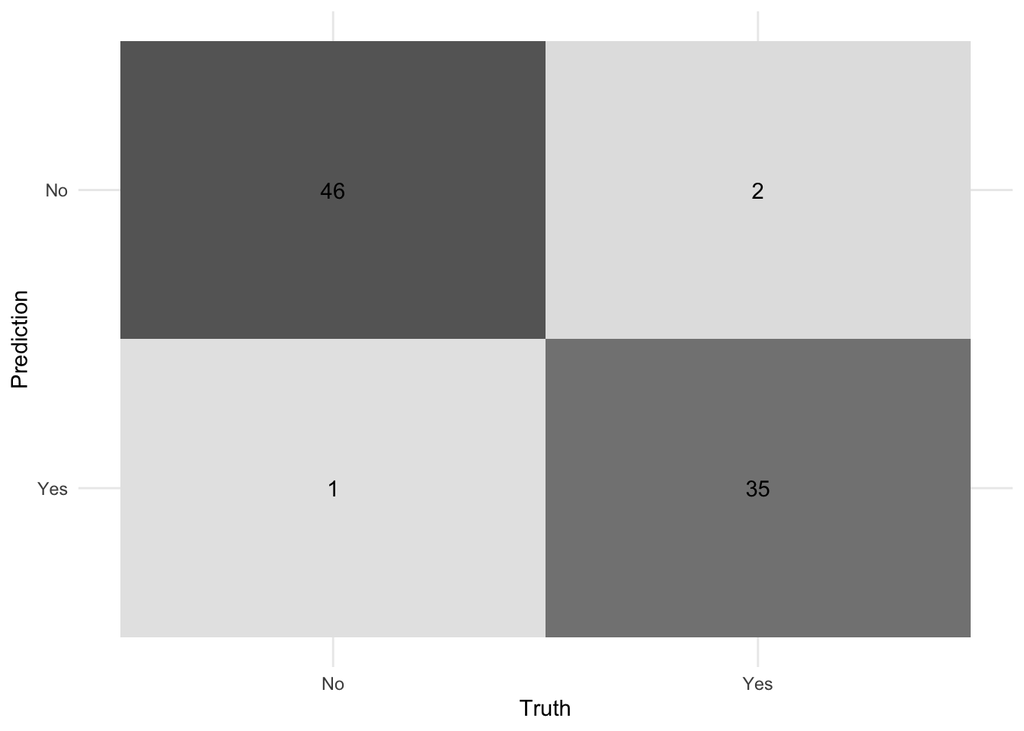

```r
log_pred |>
  conf_mat(truth = adelie, estimate = .pred_class) |>
  autoplot(type = "heatmap")
```

**TipYour turn**

How many actual Adelie penguins were correctly predicted as Adelie?

Write your answer here:

```markdown
Answer:
```

## Lab 12 — Accuracy, sensitivity and specificity

```r
log_pred |>
  metrics(truth = adelie, estimate = .pred_class)
```

```
# A tibble: 2 × 3
  .metric  .estimator .estimate
  <chr>    <chr>          <dbl>
1 accuracy binary         0.964
2 kap      binary         0.927
```

```r
log_pred |>
  sens(truth = adelie, estimate = .pred_class, event_level = "second")
```

```
# A tibble: 1 × 3
  .metric .estimator .estimate
  <chr>   <chr>          <dbl>
1 sens    binary         0.946
```

```r
log_pred |>
  spec(truth = adelie, estimate = .pred_class, event_level = "second")
```

```
# A tibble: 1 × 3
  .metric .estimator .estimate
  <chr>   <chr>          <dbl>
1 spec    binary         0.979
```

**Note**

Here the event of interest is `Yes`, so we use `event_level = "second"` because the factor levels are `No`, `Yes`.

**TipYour turn**

Is the model better at identifying Adelie penguins or non-Adelie penguins?

Write your answer here:

```markdown
Answer:
```

# Part 6 — Changing the threshold

## Lab 13 — Several thresholds

In some applications, the threshold 0.5 is not the best choice.

For example, if failing to identify an Adelie penguin is costly, we may want to use a lower threshold.

```r
log_pred_thresholds <- log_pred |>
  mutate(
    pred_0_20 = factor(if_else(.pred_Yes > 0.20, "Yes", "No"), levels = levels(penguins_binary$adelie)),
    pred_0_30 = factor(if_else(.pred_Yes > 0.30, "Yes", "No"), levels = levels(penguins_binary$adelie)),
    pred_0_40 = factor(if_else(.pred_Yes > 0.40, "Yes", "No"), levels = levels(penguins_binary$adelie)),
    pred_0_50 = factor(if_else(.pred_Yes > 0.50, "Yes", "No"), levels = levels(penguins_binary$adelie)),
    pred_0_60 = factor(if_else(.pred_Yes > 0.60, "Yes", "No"), levels = levels(penguins_binary$adelie))
  )
```

```r
threshold_summary <- log_pred_thresholds |>
  pivot_longer(
    cols = starts_with("pred_0_"),
    names_to = "threshold",
    values_to = "prediction"
  ) |>
  group_by(threshold) |>
  summarise(
    accuracy = mean(adelie == prediction),
    sensitivity = sens_vec(
      truth = adelie,
      estimate = prediction,
      event_level = "second"
    ),
    specificity = spec_vec(
      truth = adelie,
      estimate = prediction,
      event_level = "second"
    ),
    .groups = "drop"
  )

threshold_summary |>
  kbl(digits = 3) |>
  kable_styling(full_width = FALSE)
```

| threshold | accuracy | sensitivity | specificity |
| --- | --- | --- | --- |
| pred_0_20 | 0.893 | 0.946 | 0.851 |
| pred_0_30 | 0.917 | 0.946 | 0.894 |
| pred_0_40 | 0.964 | 0.946 | 0.979 |
| pred_0_5 | 0.964 | 0.946 | 0.979 |
| pred_0_50 | 0.964 | 0.946 | 0.979 |
| pred_0_60 | 0.964 | 0.919 | 1.000 |

**TipYour turn**

What happens to sensitivity when the threshold decreases?  
What happens to specificity?

Write your interpretation here:

```markdown
Interpretation:
```

## Lab 14 — Confusion matrices for different thresholds

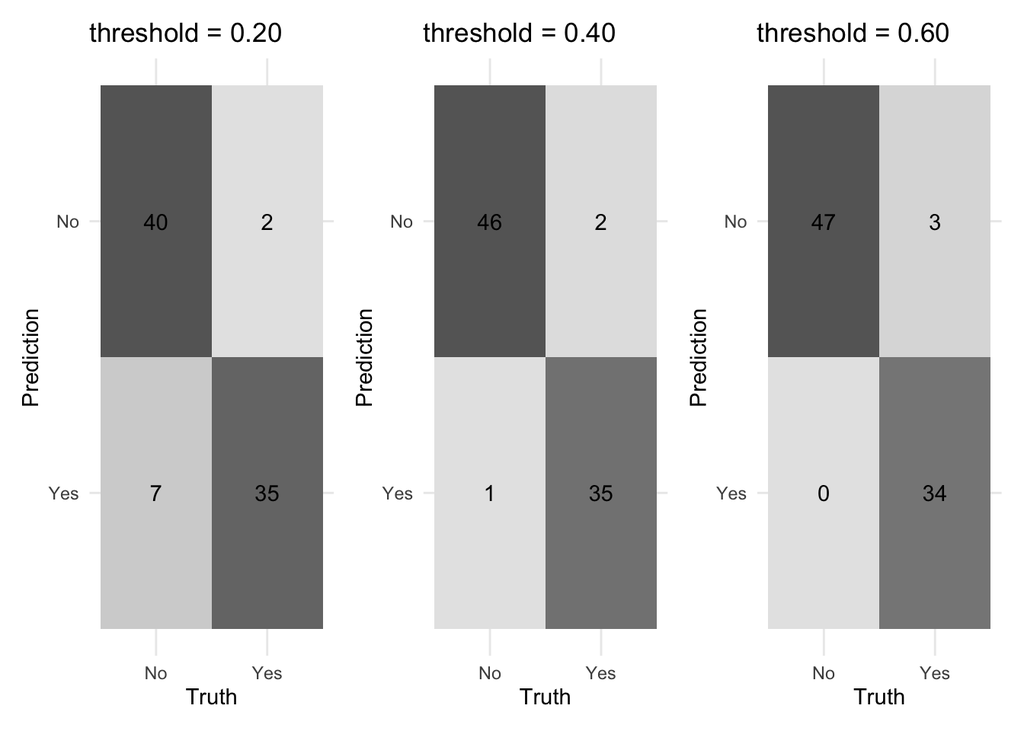

```r
p_20 <- log_pred_thresholds |>
  conf_mat(truth = adelie, estimate = pred_0_20) |>
  autoplot(type = "heatmap") +
  ggtitle("threshold = 0.20")

p_40 <- log_pred_thresholds |>
  conf_mat(truth = adelie, estimate = pred_0_40) |>
  autoplot(type = "heatmap") +
  ggtitle("threshold = 0.40")

p_60 <- log_pred_thresholds |>
  conf_mat(truth = adelie, estimate = pred_0_60) |>
  autoplot(type = "heatmap") +
  ggtitle("threshold = 0.60")

p_20 | p_40 | p_60
```

**TipYour turn**

Which threshold would you choose if missing an Adelie penguin is very costly?  
Why?

Write your answer here:

```markdown
Answer:
```

# Part 7 — ROC curve and AUC

## Lab 15 — ROC curve

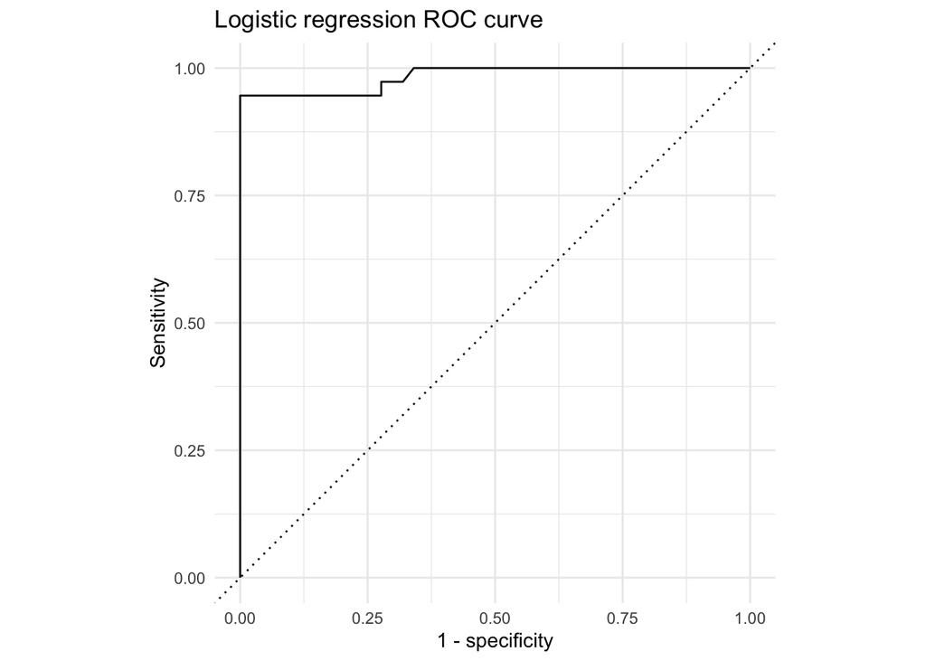

```r
log_pred |>
  roc_curve(truth = adelie, .pred_Yes, event_level = "second") |>
  ggplot(aes(x = 1 - specificity, y = sensitivity)) +
  geom_path() +
  geom_abline(lty = 3) +
  coord_equal() +
  labs(
    title = "Logistic regression ROC curve",
    x = "1 - specificity",
    y = "Sensitivity"
  )
```

## Lab 16 — AUC

```r
log_pred |>
  roc_auc(truth = adelie, .pred_Yes, event_level = "second")
```

```
# A tibble: 1 × 3
  .metric .estimator .estimate
  <chr>   <chr>          <dbl>
1 roc_auc binary         0.984
```

**TipYour turn**

What does a larger AUC mean?

Write your answer here:

```markdown
Answer:
```

# Part 8 — Adding more predictors

## Lab 17 — Multiple logistic regression

We now use several numerical predictors: bill measurements, flipper length, and body mass.

```r
peng_rec_multi <- recipe(
  adelie ~ bill_length_mm + bill_depth_mm + flipper_length_mm + body_mass_g,
  data = peng_train
)

peng_log_wflow_multi <- workflow() |>
  add_recipe(peng_rec_multi) |>
  add_model(peng_log_spec)

peng_log_fit_multi <- peng_log_wflow_multi |>
  fit(data = peng_train)

log_pred_multi <- peng_log_fit_multi |>
  augment(new_data = peng_test)
```

```r
log_pred_multi |>
  roc_auc(truth = adelie, .pred_Yes, event_level = "second")
```

```
# A tibble: 1 × 3
  .metric .estimator .estimate
  <chr>   <chr>          <dbl>
1 roc_auc binary         0.978
```

**TipYour turn**

Compare the AUC of the simple model with the AUC of the multiple-predictor model.  
Did the additional predictors help?

Write your answer here:

```markdown
Answer:
```

## Lab 18 — Probability curve

The simple model uses only `bill_length_mm`, so we can easily visualise how the predicted probability changes with bill length.

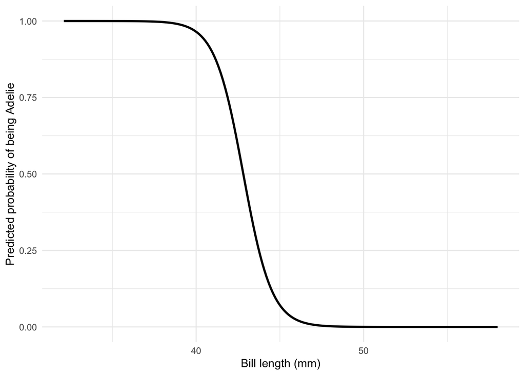

```r
new_penguins <- tibble(
  bill_length_mm = seq(
    from = min(peng_train$bill_length_mm),
    to = max(peng_train$bill_length_mm),
    length.out = 200
  )
)

pred_grid <- peng_log_fit |>
  augment(new_data = new_penguins)

pred_grid |>
  ggplot(aes(x = bill_length_mm, y = .pred_Yes)) +
  geom_line(linewidth = 1) +
  labs(
    x = "Bill length (mm)",
    y = "Predicted probability of being Adelie"
  )
```

**TipYour turn**

How does the estimated probability of being Adelie change as bill length increases?

Write your interpretation here:

```markdown
Interpretation:
```

# Part 9 — Other classifiers

## Lab 19 — Linear discriminant analysis

This section requires the `discrim` and `MASS` packages.

```r
peng_rec_discrim <- recipe(
  adelie ~ bill_length_mm + bill_depth_mm + flipper_length_mm + body_mass_g,
  data = peng_train
)

peng_lda_spec <- discrim_linear(
  mode = "classification",
  engine = "MASS"
)

peng_lda_wflow <- workflow() |>
  add_recipe(peng_rec_discrim) |>
  add_model(peng_lda_spec)

peng_lda_fit <- peng_lda_wflow |>
  fit(data = peng_train)

lda_pred <- peng_lda_fit |>
  augment(new_data = peng_test)

lda_pred |>
  roc_auc(truth = adelie, .pred_Yes, event_level = "second")
```

```
# A tibble: 1 × 3
  .metric .estimator .estimate
  <chr>   <chr>          <dbl>
1 roc_auc binary             1
```

**Note**

LDA is a generative classifier. It assumes that predictors are approximately normally distributed within each class and that classes share the same covariance structure.

## Lab 20 — Quadratic discriminant analysis

This section requires the `discrim` and `MASS` packages.

```r
peng_qda_spec <- discrim_quad(
  mode = "classification",
  engine = "MASS"
)

peng_qda_wflow <- workflow() |>
  add_recipe(peng_rec_discrim) |>
  add_model(peng_qda_spec)

peng_qda_fit <- peng_qda_wflow |>
  fit(data = peng_train)

qda_pred <- peng_qda_fit |>
  augment(new_data = peng_test)

qda_pred |>
  roc_auc(truth = adelie, .pred_Yes, event_level = "second")
```

```
# A tibble: 1 × 3
  .metric .estimator .estimate
  <chr>   <chr>          <dbl>
1 roc_auc binary             1
```

**Note**

QDA relaxes the common covariance assumption. This allows more flexible, curved decision boundaries.

QDA can fail when predictors are highly redundant or when the class-specific covariance matrix cannot be estimated reliably.

## Lab 21 — Naive Bayes

This section requires the `discrim` and `naivebayes` packages.

```r
peng_nb_spec <- naive_Bayes(
  mode = "classification",
  engine = "naivebayes"
)

peng_nb_wflow <- workflow() |>
  add_recipe(peng_rec_discrim) |>
  add_model(peng_nb_spec)

peng_nb_fit <- peng_nb_wflow |>
  fit(data = peng_train)

nb_pred <- peng_nb_fit |>
  augment(new_data = peng_test)

nb_pred |>
  roc_auc(truth = adelie, .pred_Yes, event_level = "second")
```

```
# A tibble: 1 × 3
  .metric .estimator .estimate
  <chr>   <chr>          <dbl>
1 roc_auc binary         0.987
```

**Note**

Naive Bayes assumes that predictors are independent within each class. The assumption is strong, but the method can work well in practice.

## Lab 22 — Compare classifiers

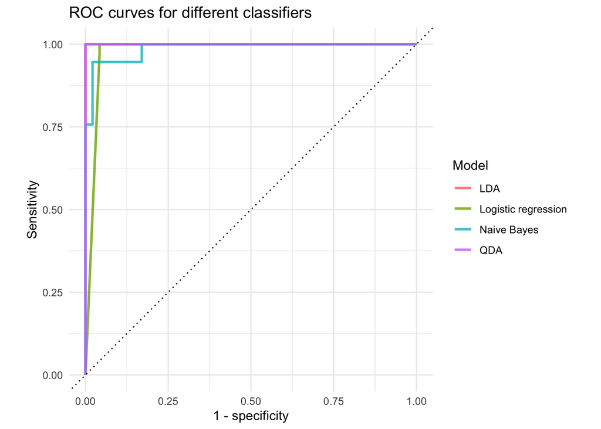

```r
roc_all <- bind_rows(
  log_pred_multi |>
    roc_curve(truth = adelie, .pred_Yes, event_level = "second") |>
    mutate(model = "Logistic regression"),

  lda_pred |>
    roc_curve(truth = adelie, .pred_Yes, event_level = "second") |>
    mutate(model = "LDA"),

  qda_pred |>
    roc_curve(truth = adelie, .pred_Yes, event_level = "second") |>
    mutate(model = "QDA"),

  nb_pred |>
    roc_curve(truth = adelie, .pred_Yes, event_level = "second") |>
    mutate(model = "Naive Bayes")
)

roc_all |>
  ggplot(aes(x = 1 - specificity, y = sensitivity, colour = model)) +
  geom_path(linewidth = 1, alpha = 0.8) +
  geom_abline(lty = 3) +
  coord_equal() +
  labs(
    title = "ROC curves for different classifiers",
    x = "1 - specificity",
    y = "Sensitivity",
    colour = "Model"
  )
```

```r
auc_all <- bind_rows(
  log_pred_multi |>
    roc_auc(truth = adelie, .pred_Yes, event_level = "second") |>
    mutate(model = "Logistic regression"),

  lda_pred |>
    roc_auc(truth = adelie, .pred_Yes, event_level = "second") |>
    mutate(model = "LDA"),

  qda_pred |>
    roc_auc(truth = adelie, .pred_Yes, event_level = "second") |>
    mutate(model = "QDA"),

  nb_pred |>
    roc_auc(truth = adelie, .pred_Yes, event_level = "second") |>
    mutate(model = "Naive Bayes")
)

auc_all |>
  select(model, .estimate) |>
  arrange(desc(.estimate)) |>
  kbl(digits = 3) |>
  kable_styling(full_width = FALSE)
```

| model | .estimate |
| --- | --- |
| LDA | 1.000 |
| QDA | 1.000 |
| Naive Bayes | 0.987 |
| Logistic regression | 0.978 |

**TipYour turn**

Which classifier has the largest AUC?  
Is the difference large enough to matter in practice?

Write your answer here:

```markdown
Answer:
```

# Optional — Multi-class classification

So far, we transformed the problem into a binary classification task.

We can also predict the original `species` variable.  
This is a multi-class classification problem.

## Lab 23 — Prepare the multi-class data

```r
penguins_multi <- palmerpenguins::penguins |>
  drop_na(
    species,
    bill_length_mm,
    bill_depth_mm,
    flipper_length_mm,
    body_mass_g
  ) |>
  mutate(species = as.factor(species))

set.seed(1234)

peng_multi_split <- initial_split(
  penguins_multi,
  prop = 3/4,
  strata = species
)

peng_multi_train <- training(peng_multi_split)
peng_multi_test <- testing(peng_multi_split)
```

## Lab 24 — Fit a multinomial logistic regression

```r
peng_multi_rec <- recipe(
  species ~ bill_length_mm + bill_depth_mm + flipper_length_mm + body_mass_g,
  data = peng_multi_train
)

peng_multi_spec <- multinom_reg(
  mode = "classification",
  engine = "nnet"
)

peng_multi_wflow <- workflow() |>
  add_recipe(peng_multi_rec) |>
  add_model(peng_multi_spec)

peng_multi_fit <- peng_multi_wflow |>
  fit(data = peng_multi_train)

peng_multi_pred <- peng_multi_fit |>
  augment(new_data = peng_multi_test)

peng_multi_pred |>
  conf_mat(truth = species, estimate = .pred_class)
```

```
           Truth
Prediction  Adelie Chinstrap Gentoo
  Adelie        34         0      0
  Chinstrap      2        17      1
  Gentoo         2         0     30
```

**TipYour turn**

Which species are easiest to classify?  
Which species are most often confused?

Write your answer here:

```markdown
Answer:
```

# Final reflection

Write a short paragraph answering the following questions:

1. What is the difference between a predicted probability and a predicted class?
2. Why can changing the threshold change the type of errors we make?
3. Why is accuracy sometimes misleading in imbalanced classification problems?
4. Which part of the classification workflow would you use in your own research?

```markdown
Final reflection:
```